# InVivoStat Correlation Analysis

## Responses

This module assesses the correlation between the response variables Resp12 and Resp13.

## Warning

Warning: One or more of the responses consists of only one or two observations, please remove these prior to the analysis as it is not possible to calculate correlations with them.

### Scatterplot of the observed data

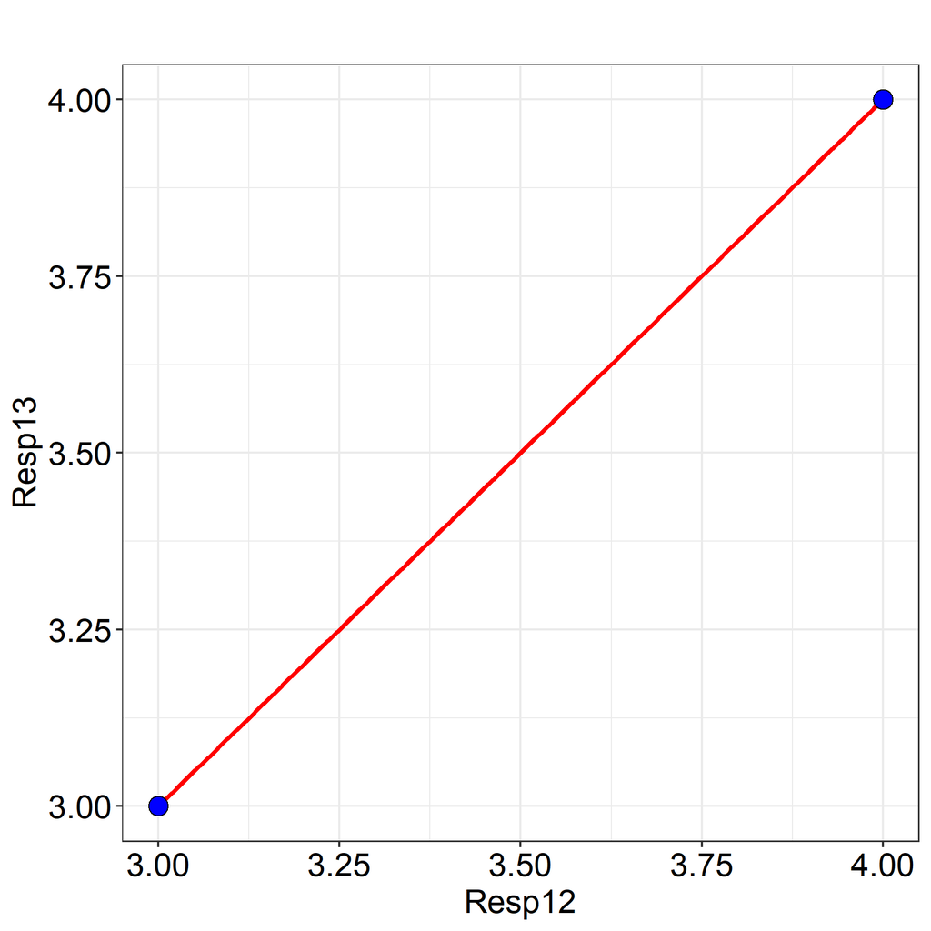

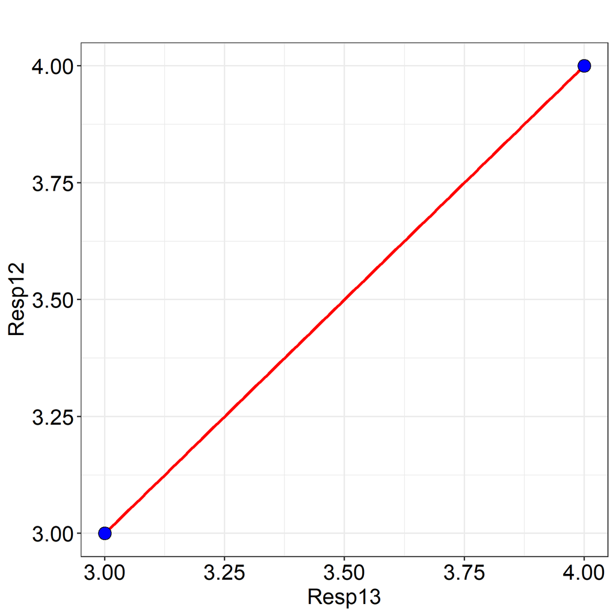

### Matrixplot, including linear regression lines

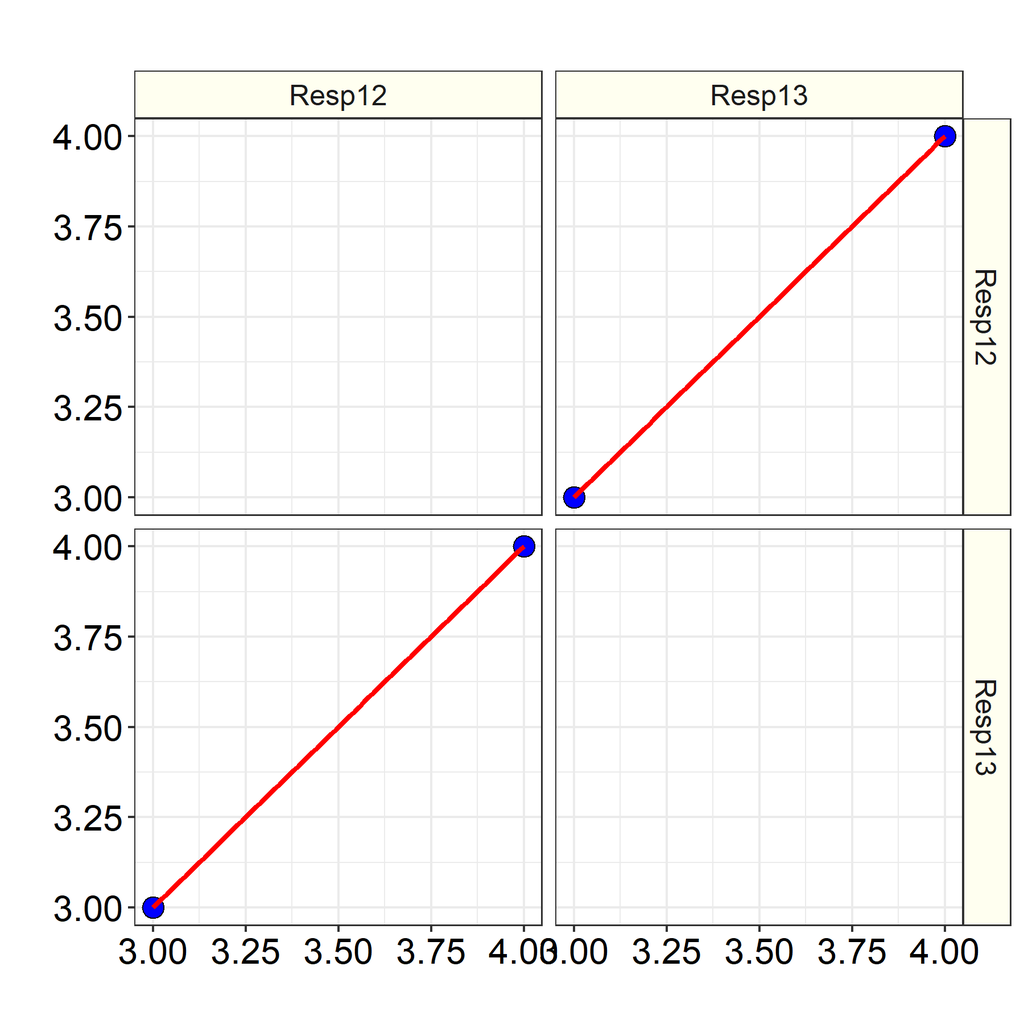

## Analysis description

The test statistic is based on Pearson's product moment correlation coefficient cor(x, y) and follows a t distribution with length(x)-2 degrees of freedom if the samples follow independent normal distributions, see Snedecor and Cochran (1989).

For more information on the theoretical approaches that are implemented within this module, see Bate and Clark (2014).

## References

When referring to InVivoStat, please cite 'InVivoStat, version 5.2.0'.

Bate, S.T. and Clark, R.A. (2014). The Design and Statistical Analysis of Animal Experiments. Cambridge University Press.

Snedecor, G.W. and Cochran, W.G. (1989). Statistical Methods. 8th edition; Iowa State University Press, Iowa, USA.